# Reproducible Research

### 1. Code for reading in the dataset and/or processing the data

First you need to call the database from your directory, indicating the packages you will use during this exercise. I’ve used the function sum to find the total steps taken by day.

```r
library(readr)
activity <- read_csv("~/coursera/Reproducible Research/activity.csv")
View(activity)
library(ggplot2)
library(dplyr)
Sys.setlocale("LC_TIME", "English")
str(activity)
StepsPerDay <- aggregate(activity$steps, list(activity$date), FUN=sum)
colnames(StepsPerDay) <- c("Date", "Steps")
StepsPerDay
```

[output not shown]

### 2. Histogram of the total number of steps taken each day

Here you can find the code to build a histogram of the total steps taken each day.

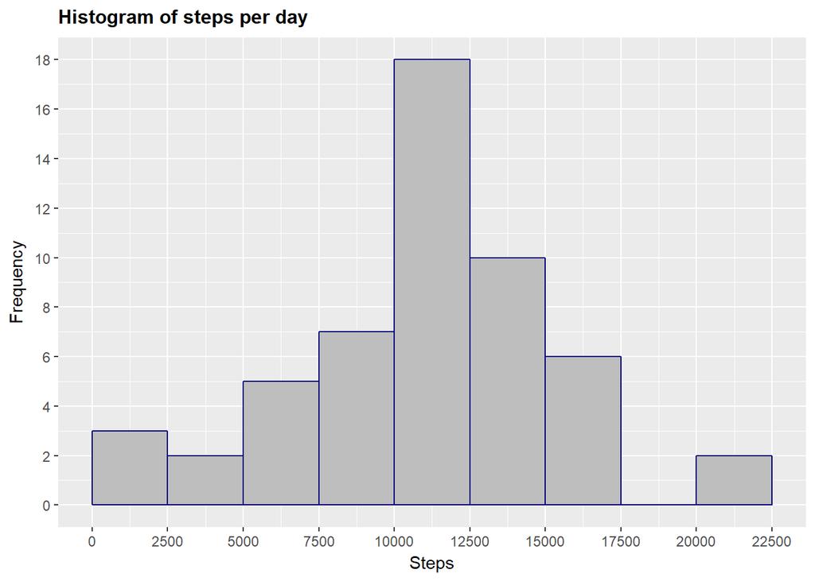

```r
g <- ggplot(StepsPerDay, aes(Steps))
g+geom_histogram(boundary=0, binwidth=2500, col="navy", fill="gray")+ggtitle("Histogram of steps per day")+xlab("Steps")+ylab("Frequency")+theme(plot.title = element_text(face="bold", size=12))+scale_x_continuous(breaks=seq(0,25000,2500))+scale_y_continuous(breaks=seq(0,18,2))
```

### 3. Mean and median number of steps taken each day

```r
mean(StepsPerDay$Steps, na.rm=TRUE)
```

```
## [1] 10766.19
```

```r
median(StepsPerDay$Steps, na.rm=TRUE)
```

```
## [1] 10765
```

### 4. Time series plot of the average number of steps taken

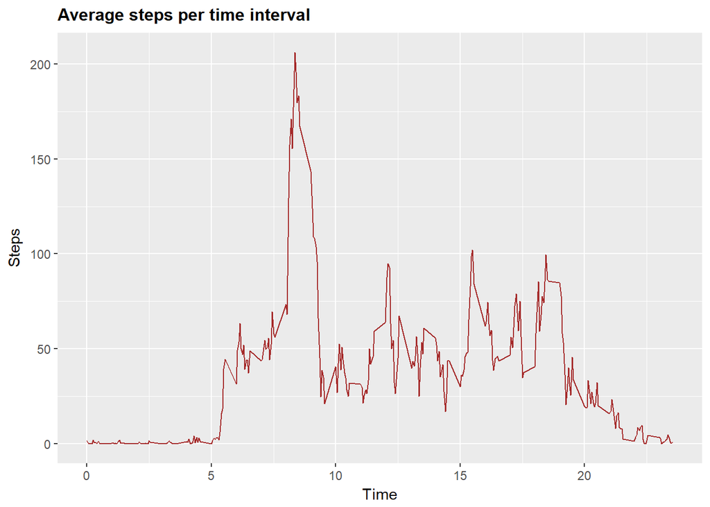

```r
StepsPerTime <- aggregate(steps~interval,data=activity,FUN=mean,na.action=na.omit)
StepsPerTime$time <- StepsPerTime$interval/100
h <- ggplot(StepsPerTime, aes(time, steps))
h+geom_line(col="brown")+ggtitle("Average steps per time interval")+xlab("Time")+ylab("Steps")+theme(plot.title = element_text(face="bold", size=12))
```

### 5. The 5-minute interval that, on average, contains the maximum number of steps

```r
ST <- as_tibble (StepsPerTime)
ST %>% select(time, steps) %>% filter(steps==max(ST$steps))
```

```
## # A tibble: 1 x 2
##    time    steps
##   <dbl>    <dbl>
## 1  8.35 206.1698
```

```r
activity$CompleteSteps <- ifelse(is.na(activity$steps), round(StepsPerTime$steps[match(activity$interval, StepsPerTime$interval)],0), activity$steps)
activityFull <- data.frame(steps=activity$CompleteSteps, interval=activity$interval, date=activity$date)
head(activityFull, n=10)
```

```
##    steps interval       date
## 1      2        0 2012-10-01
## 2      0        5 2012-10-01
## 3      0       10 2012-10-01
## 4      0       15 2012-10-01
## 5      0       20 2012-10-01
## 6      2       25 2012-10-01
## 7      1       30 2012-10-01
## 8      1       35 2012-10-01
## 9      0       40 2012-10-01
## 10     1       45 2012-10-01
```

### 7. Histogram of the total number of steps taken each day after missing values are imputed

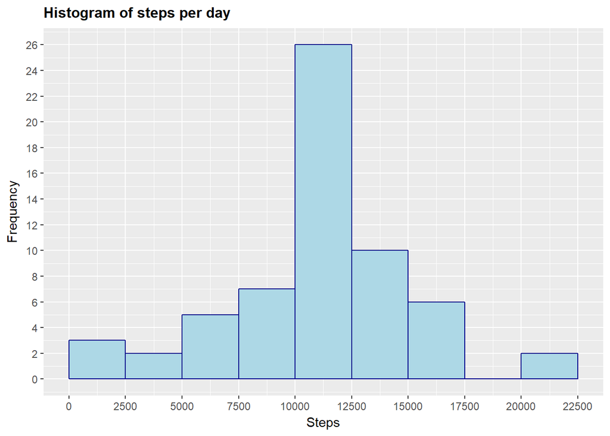

```r
StepsPerDayFull <- aggregate(activityFull$steps, list(activityFull$date), FUN=sum)
colnames(StepsPerDayFull) <- c("Date", "Steps")
g <- ggplot(StepsPerDayFull, aes(Steps))
g+geom_histogram(boundary=0, binwidth=2500, col="darkblue", fill="lightblue")+ggtitle("Histogram of steps per day")+xlab("Steps")+ylab("Frequency")+theme(plot.title = element_text(face="bold", size=12))+scale_x_continuous(breaks=seq(0,25000,2500))+scale_y_continuous(breaks=seq(0,26,2))
```

```r
mean(StepsPerDayFull$Steps)
```

```
## [1] 10765.64
```

```r
median(StepsPerDayFull$Steps)
```

```
## [1] 10762
```

First it will need to transform the date into weekdays: Monday, Tuesday, Wednesday, Thursday, Friday, Saturday and Sunday.

```r
activityFull$RealDate <- as.Date(activityFull$date, format = "%Y-%m-%d")
activityFull$weekday <- weekdays(activityFull$RealDate)
head(activityFull, n=10)
```

[output not shown]

```r
activityFullselect <- select(activityFull, steps, weekday)
head(activityFullselect)

StepsPerweekday <- aggregate(steps~ weekday,data=activityFull,FUN=mean,na.action=na.omit)
StepsPerTime$time <- StepsPerTime$interval/100
StepsPerweekday
```

[output not shown]

Finally, plot the average steps taken by each weekday.

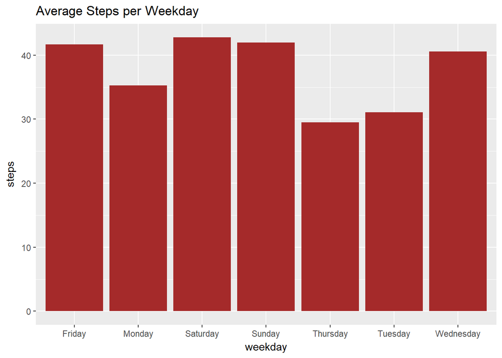

```r
h <- ggplot( data = activityFull, aes(weekday, steps))
h <- h + stat_summary(fun.y = mean, geom = "bar", fill= "brown") + ggtitle("Average Steps per Weekday")
h
```